# Pós-graduação em Ciências Veterinárias (IV/UFRRJ)

Modelo de Regressão Logística

Adriana Andrade Wagner Tassinari

2021

# Modelo de Regressão Logística (MRLog)

O modelo de regressão logística costuma ser aplicado em estudos nos quais a variável de interesse é categórica dicotômica, ou seja, possui unicamente dois desfechos possíveis.

Nessa modelagem, os valores preditos serão a probabilidade da ocorrência de um dado desfecho, ou seja, a variável resposta Y modela uma probabibilidade e seus valores estarão no intervalo entre 0 e 1.

O Modelo de Regressão Logística (MRLog) faz parte da classe dos Modelos Lineares Generalizados, casos nos quais a distribuição dos erros não possui uma distribuição Normal.

O objetivo dos Modelos Lineares Generalizados é obter para uma variável resposta que não é quantitativa contínua uma relação linear nos parâmetros das variáveis preditoras, ou seja, um preditor linear $\eta = \beta_0 +\beta_1X_{1i}$, a partir de uma função de ligação que relaciona a variável resposta com as variáveis preditoras.

A função de ligação utilizada no Modelo de Regressão Logística é a função logit.

O logit é uma variável contínua e é calculado como o logaritmo natural da vantagem **odds** que representa a razão entre a probabilidade de ocorrência e a probabilidade de não-ocorrência do desfecho de interesse.

$logit = ln(odds) =ln \left ( \frac{p}{1-p} \right )$

# Transformação Logit da probabilidade *p*

Com o uso da quantidade **logit** obtém-se o seguinte modelo:

$ln \left ( \frac{\hat{p}}{1-\hat{p}} \right ) = \hat{\beta}_0+\hat{\beta}_{1}X_1+\hat{\beta}_{2}X_2+...+\hat{\beta}_{K}X_k$

Para reescrever o modelo ajustado em função da probabilidade de ocorrência do desfecho de interesse, aplica-se a função exponencial na equação anterior:

$\hat{p_i}= \frac {e^{\beta_0 + \beta_1X}}{1 +e^{(\beta_0 + \beta_1X)}} = \frac {1}{1 +e^{-(\beta_0 + \beta_1X)}}$

# Prática

- Base de dados: daisy2.xlsx
- Conjunto de dados proveniente de um estudo tipo coorte a respeito das condições do manejo reprodutivo em rebanhos de bovinos leiteiros. O objetivo é avaliar o desempenho reprodutivo e a produção de leite desses animais.

## Preparação do banco de dados

- Abra o banco de dados:

```r
library(readxl)
daisy2 <- read_excel("G:/Meu Drive/Projects/MLG_2021/Bancos/daisy2.xlsx")

daisy2 <- daisy2[daisy2$h7 == 1, ] # vamos apenas usar um subconjunto dos dados

head(daisy2)
```

```
# A tibble: 6 x 19
  region  herd   cow study_lact herd_size   mwp parity milk120 calv_dt    cf
   <dbl> <dbl> <dbl>      <dbl>     <dbl> <dbl>  <dbl>   <dbl>   <dbl> <dbl>
1      1     1     1          1       294    26      5   3506.   13464    80
2      1     1     2          1       294    26      5   3691.   13526    64
3      1     1     3          1       294    26      5   4173    13531    71
4      1     1     4          1       294    26      5   3727.   13556    35
5      1     1     5          1       294    26      5   3091.   13691    47
6      1     1     6          1       294    26      4   5041.   13438    NA
# ... with 9 more variables: fs <dbl>, cc <dbl>, wpc <dbl>, spc <dbl>,
#   twin <dbl>, dyst <dbl>, rp <dbl>, vag_disch <dbl>, h7 <dbl>
```

Ou siga as seguintes etapas no RStudio: *Environment –> Import Dataset –> From Excel…*

- Selecione as variáveis para compor o banco que será trabalhado
  - *cow* - Identificador do animal
  - *dyst* - Complicações no parto (Distocia fetal)
  - *milk120* - Litros de leite nos primeiros 120 dias de lactação
  - *mwp* - Período de espera até a concepção
  - *parity* - Número de lactação
  - *twin* - Nascimento duplo
  - *rp* - Retenção da placenta no parto
  - *vag_disch* - Corrimento vaginal observado

```r
myvars <- c("cow", "dyst", "milk120", "mwp", "parity", "twin", "rp", "vag_disch")
banco <- daisy2[myvars]

head(banco)
```

```
# A tibble: 6 x 8
    cow  dyst milk120   mwp parity  twin    rp vag_disch
  <dbl> <dbl>   <dbl> <dbl>  <dbl> <dbl> <dbl>     <dbl>
1     1     0   3506.    26      5     0     0         0
2     2     0   3691.    26      5     0     0         0
3     3     0   4173     26      5     0     0         0
4     4     0   3727.    26      5     0     0         0
5     5     0   3091.    26      5     0     0         0
6     6     0   5041.    26      4     0     1         0
```

## Verificação de valores ausentes

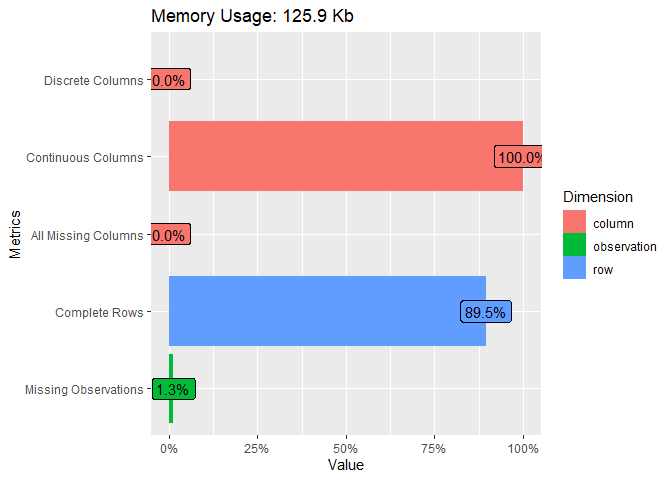

```r
#Verificação de Missing values na base de dados

library(DataExplorer)

plot_intro(banco)
```

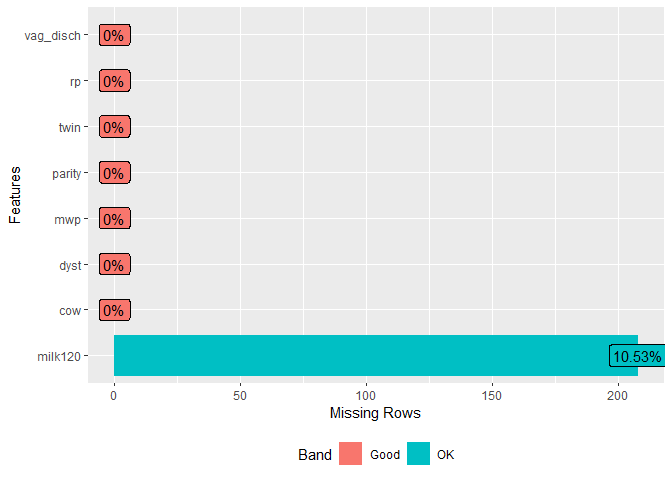

```r
plot_missing(banco)
```

## Tratamento dos Valores Ausentes

Iremos excluir os valores ausentes da base sob análise pelo fato de se tratar de um exercício. Em geral, esse recurso deve ser o último a ser adotado. Uma maneira de tatar os valores ausentes é o uso de algum método de imputação.

**Excluindo os missings na var milk120**

```r
banco <- subset(banco, milk120 != is.na(milk120))
```

**Panorama geral do banco**

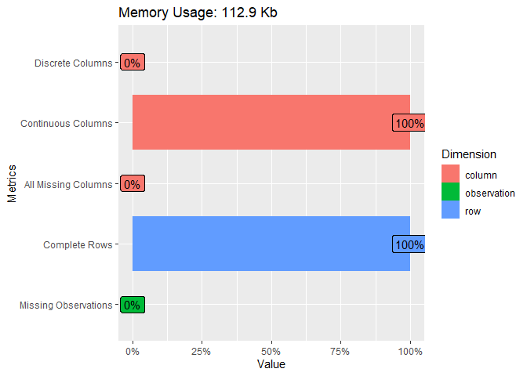

```r
library(DataExplorer)
plot_intro(banco)
```

## Formatação das variáveis

```r
# Colocando os labels nas variáveis categóricas

# Complicações no parto
banco$dyst <- factor(banco$dyst, labels = c("Nao", "Sim"))
banco$dyst <- relevel(banco$dyst, "Nao")

# Nascimento duplo
banco$twin <- factor(banco$twin, labels = c("Nao", "Sim"))
banco$twin <- relevel(banco$twin, "Nao")

# Retenção da placenta no parto
banco$rp <- factor(banco$rp, labels = c("Nao", "Sim"))
banco$rp <- relevel(banco$rp, "Nao")

# Corrimento vaginal observado
banco$vag_disch <- factor(banco$vag_disch, labels = c("Nao", "Sim"))
banco$vag_disch <- relevel(banco$vag_disch, "Nao")

# Categorizando a variável parity
banco$parity_cat <- cut((banco$parity), breaks = c(0, 1, 3, 7), labels = c("1", "2-3","Mais de 4"))
banco$parity_cat<-relevel(banco$parity_cat,"1")
table(banco$parity_cat)
```

```
        1       2-3 Mais de 4
      438       747       583
```

# Ajuste do Modelo

Vamos supor que estamos interessados em estudar a relação entre a variável **Complicações no parto (Distocia fetal) - dyst** e algumas variáveis explicativas presentes no banco de dados.

## Análise bivariada, utilizando a variável complicações no parto como desfecho

```r
library(tableone)

myVars2 <- c("milk120", "mwp", "twin", "rp", "vag_disch", "parity_cat")

tabela2 <- CreateTableOne(vars = myVars2, strata = "dyst",                                             data = banco)
print(tabela2, showAllLevels = TRUE)
```

```
                     Stratified by dyst
                      level     Nao              Sim              p      test
  n                                1662              106
  milk120 (mean (SD))           3235.66 (708.24) 3063.10 (601.85)  0.014
  mwp (mean (SD))                 35.85 (10.46)    40.36 (7.63)   <0.001
  twin (%)            Nao          1623 (97.7)       103 (97.2)    1.000
                      Sim            39 ( 2.3)         3 ( 2.8)
  rp (%)              Nao          1499 (90.2)        88 (83.0)    0.028
                      Sim           163 ( 9.8)        18 (17.0)
  vag_disch (%)       Nao          1580 (95.1)        87 (82.1)   <0.001
                      Sim            82 ( 4.9)        19 (17.9)
  parity_cat (%)      1             380 (22.9)        58 (54.7)   <0.001
                      2-3           721 (43.4)        26 (24.5)
                      Mais de 4     561 (33.8)        22 (20.8)
```

## Estimação dos Parâmetros do MRLog

Os coeficientes do modelo de regressão logística serão estimados pelo Método da Máxima Verossimilhança.

```r
mrlog1<-glm(dyst~vag_disch, family = "binomial",data=banco)

mrlog1$coefficients
```

```
 (Intercept) vag_dischSim
   -2.899272     1.436992
```

**Modelo ajustado**: $ln \left ( \frac{\hat{p}}{1-\hat{p}} \right ) = -2.899 + 1.437X_i(vag.disch)$

onde:

$ln ( ) $ representa o logaritmo da chance de apresentar complicações no parto.

$X_i(vag.disch)$ a variável indicadora de presença de corrimento vaginal.

Com base no sinal do coeficiente estimado, concluímos que o efeito da variável explicativa representa um aumento no logit.

## Interpretação - Análise da odds ratio (OR)

A *odds ratio* (OR) compara a probabilidade de ocorrência do evento de interesse para níveis distintos de uma variável explicativa e fornece o efeito do coeficiente estimado na chance do desfecho de interesse.

$$OR=\frac{p_{A_1}/(1-p_{A_1})}{p_{A_2}/(1-p_{A_2})}$$

Tendo em vista que o logit é mensurado na escala logarítmica, a exponenciação do parâmetro de regressão $\beta$ fornece o efeito de OR:

| Quantidade | Interpretação |
| --- | --- |
| $$exp(\hat{\beta})>1$$ | aumento da chance |
| $$exp(\hat{\beta})<1$$ | diminição da chance |
| $$[exp(\hat{\beta})-1]\times 100 = \%$$ | mudança percentual na chance |

Para avaliar o efeito da variável explicativa na chance de ocorrência de complicações no parto é preciso calcular o $exp(\beta)= exp(1.437)=4,21$. Ou seja, a $OR$ de complicações no parto é 4.21 vezes maior de ocorrer quando há corrimento vaginal.

## Teste de Hipóteses na Regressão Logística

Hipóteses:

$H_0:\beta_1 = 0$

$H_1:\beta_1 \neq 0$

**Estatística de Wald**

$Wald = \frac{\hat{\beta}_j}{se(\hat{\beta}_j)}\sim N(0,1)$

```r
summary(mrlog1)$coefficients
```

```
              Estimate Std. Error   z value      Pr(>|z|)
(Intercept)  -2.899272  0.1101194 -26.32843 9.065941e-153
vag_dischSim  1.436992  0.2774040   5.18014  2.217192e-07
```

## Intervalo de Confiança para $\beta$

Além das estimativas pontuais dos coeficientes, é possível obter estimativas intervalares para esses parâmetros com base em suas distribuições de probabilidade.

A amplitude desses intervalos revela informações sobre a qualidade geral da reta de regressão.

Rejeita-se $H_0$ quando o intervalo de confiança estimado não contiver o zero.

```r
confint(mrlog1)
```

[output not shown]

Uma avaliação mais frequentemente utilizada relacionada com os coeficientes da regressão logística ocorre pela verificação do intervalo de confiança dos coeficientes exponenciados. Nesse caso, se o intervalo contiver o valor $1$ tem-se evidências de que o a variável explicativa não apresenta um efeito significativo na chance de ocorrência do desfecho de interesse.

|  | Modelo Ajustado |  |
| --- | --- | --- |
| Predictors | exp(B) | IC 95% |
| (Intercept) | 0.06 | 0.04 – 0.07 |
| vag_disch [Sim] | 4.21 | 2.39 – 7.12 |

# Predição

## Valores Preditos - Probabilidades

```r
#Obtenção dos valores preditos pelo modelo
p<-fitted(mrlog1)

min(p)
```

```
[1] 0.05218956
```

```r
max(p)
```

```
[1] 0.1881188
```

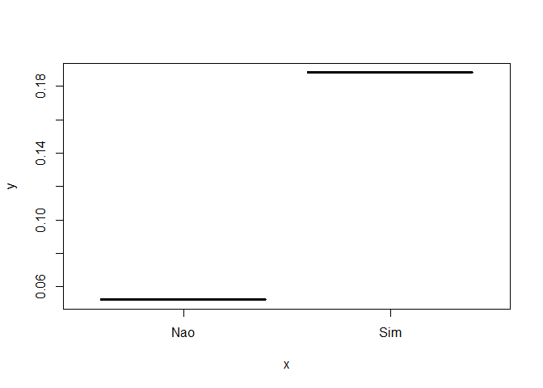

```r
plot(banco$vag_disch, p)
```

# Seleção do Modelo

Modelos Univariados

## Seleção de Variáveis via *Stepwise*

- O **stepwise** é um procedimento que podemos usar para construir um modelo de regressão a partir de um conjunto de variáveis preditoras, inserindo e removendo preditores de maneira gradual no modelo até que não haja nenhuma razão estatisticamente válida para inserir ou remover mais variáveis.

```r
# Modelo com todas as variáveis
modelo.cheio <- glm(dyst ~  vag_disch + twin + rp +  milk120 + mwp + parity_cat , family = "binomial", data = banco)


# Modelo sem variáveis independentes
modelo.vazio <- glm(dyst ~ 1, family="binomial", data = banco)

library(MASS)
# Modelo ajustado via Backward
m_backward <- stepAIC(modelo.cheio, scope = list(upper = modelo.cheio, lower = modelo.vazio),
                      direction = "backward")
```

```
Start:  AIC=734.01
dyst ~ vag_disch + twin + rp + milk120 + mwp + parity_cat

             Df Deviance    AIC
- twin        1   718.02 732.02
- milk120     1   718.12 732.12
- rp          1   719.94 733.94
<none>            718.01 734.01
- vag_disch   1   731.74 745.74
- mwp         1   734.11 748.11
- parity_cat  2   748.55 760.55

Step:  AIC=732.02
dyst ~ vag_disch + rp + milk120 + mwp + parity_cat

             Df Deviance    AIC
- milk120     1   718.12 730.12
- rp          1   719.97 731.97
<none>            718.02 732.02
- vag_disch   1   732.09 744.09
- mwp         1   734.14 746.14
- parity_cat  2   749.00 759.00

Step:  AIC=730.12
dyst ~ vag_disch + rp + mwp + parity_cat

             Df Deviance    AIC
- rp          1   720.04 730.04
<none>            718.12 730.12
- vag_disch   1   732.49 742.49
- mwp         1   735.38 745.38
- parity_cat  2   760.27 768.27

Step:  AIC=730.04
dyst ~ vag_disch + mwp + parity_cat

             Df Deviance    AIC
<none>            720.04 730.04
- vag_disch   1   737.03 745.03
- mwp         1   737.58 745.58
- parity_cat  2   761.48 767.48
```

```r
m_forward <- stepAIC(modelo.cheio, scope = list(upper = modelo.cheio, lower = modelo.vazio),
                     direction = "forward")
```

```
Start:  AIC=734.01
dyst ~ vag_disch + twin + rp + milk120 + mwp + parity_cat
```

# Qualidade do Ajuste

## Razão de Verossimilhança

Esse teste compara a verossimilhança do modelo de pesquisa (com todos os preditores incluídos) com a verossimilhança do modelo nulo (que contém apenas o intercepto).

$$RV = -2ln\frac{L_{pesq}}{L_0}-2(lnL_{pesq} -lnL_0)$$

$H_0$: modelo de pesquisa não é adequado

O teste também pode ser utilizado para se comparar outros modelos aninhados, ou seja, o modelo mais simples é formado por um subconjunto das variáveis do modelo completo.

No desenvolvimento da prática de sala de aula, iremos comparar os dois modelos ajustados: m_backward,m_forward. De acordo com o teste da Razão de Verossimilhanças, a diferença entre os dois modelos não é estatisticamente significativa. Isto indica que a inclusão das variáveis do modelo completo não representou um ganho significativo.

```r
library("lmtest")
lrtest(m_backward,m_forward)
```

```
Likelihood ratio test

Model 1: dyst ~ vag_disch + mwp + parity_cat
Model 2: dyst ~ vag_disch + twin + rp + milk120 + mwp + parity_cat
  #Df  LogLik Df  Chisq Pr(>Chisq)
1   5 -360.02
2   8 -359.01  3 2.0224     0.5678
```

## Estatísticas de Avaliação da Qualidade do Ajuste - Pseudo $R^2$

```r
library(blorr)
blr_rsq_nagelkerke(m_backward)
```

```
[1] 0.1243813
```

## Validação do Modelo - Teste de Hosmer e Lemeshow

$H_0$: proporções observadas e esperadas são iguais => modelo bem ajustado.

```r
library(blorr)
blr_test_hosmer_lemeshow(m_backward)
```

```
           Partition for the Hosmer & Lemeshow Test
--------------------------------------------------------------
                        def = 1                 def = 0
Group    Total    Observed    Expected    Observed    Expected
--------------------------------------------------------------
  1       201        1          2.63        200        198.37
  2       165        3          2.71        162        162.29
  3       209        7          5.14        202        203.86
  4       210        9          6.98        201        203.02
  5       114        9          4.22        105        109.78
  6       197        1          9.14        196        187.86
  7       174        9          9.33        165        164.67
  8       147        9          9.96        138        137.04
  9       239        36        30.63        203        208.37
 10       112        22        25.26         90        86.74
--------------------------------------------------------------

     Goodness of Fit Test
------------------------------
Chi-Square    DF    Pr > ChiSq
------------------------------
 17.3288      8       0.0269
------------------------------
```

## Validação do Modelo - Curva ROC

A Curva ROC no contexto do modelo de regressão logística permite avaliar o potencial da capacidade preditiva do modelo estimado a partir da relação entre as medidas de sensibilidade (*verdadeiros positivos*) e de especificidade (*verdadeiros negativos*).

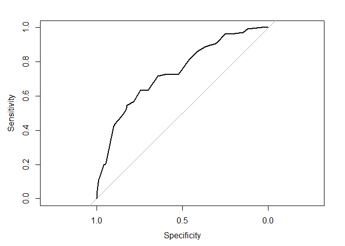

```r
library(pROC)
roc1<- plot.roc(banco$dyst,fitted(m_backward))
```

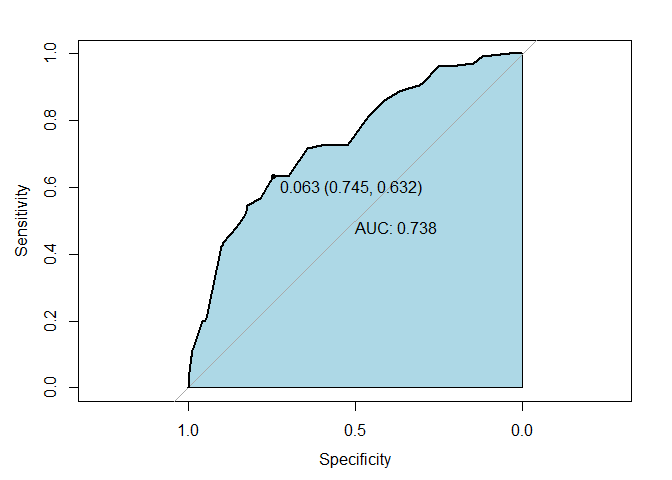

```r
plot(roc1,
     print.auc=TRUE,
     auc.polygon=TRUE,
     auc.polygon.col="lightblue",
     print.thres=TRUE
     )
```

# Adequação do Ajuste

## Verificação de multicolinearidade e de outliers

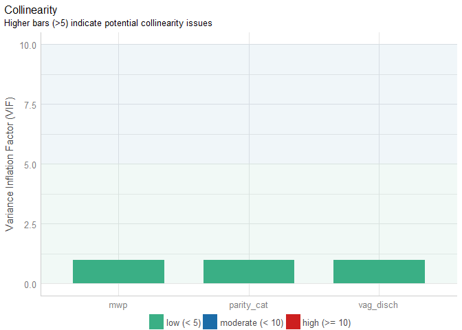

```r
library(performance)

plot(check_collinearity(m_backward))
```

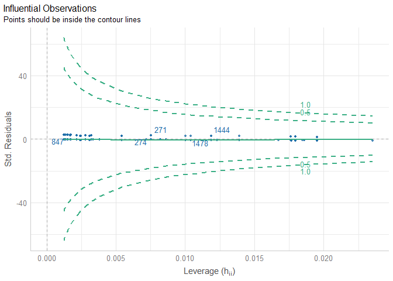

```r
plot(check_outliers(m_backward))
```

# Análise do modelo

Equação do modelo

$ln \left ( \frac{\hat{p}_{dyst}}{1-\hat{p}_{dyst}} \right )=\hat{\beta}_0 +\hat{\beta}_{1}X_1(vag.disch)+\hat{\beta}_{2}X_2(mwp)+\hat{\beta}_{K3}X_3(parity.23)+\hat{\beta}_{K4}X_4(parity.4)$

## Interpretação dos coeficientes do modelo

[output not shown]

$\hat{\beta_1}(vag_disch)$ - ter corrimento vaginal aumenta em 3.7 vezes a chance de ocorrência de complicações,ou observa-se um aumento de $[exp(1.307)-1]*100 = (3,70-1)*100 = 270%$;

$\hat{\beta_2}(parity.23)$ - ter 2 ou 3 partos em comparação a ter 1 parto diminui em 0.25 vezes ou em 75% a chance de ter complicações.

$\hat{\beta_2}(parity.4)$ - ter 4 ou mais partos em comparação a ter um parto diminui em 0.27 vezes ou em 73% a chance de ter complicações.

[figure not shown]

```r
#https://strengejacke.github.io/sjPlot/articles/plot_model_estimates.html#labelling-the-plot
#library(sjPlot)
plot_model(m_backward,
           transform = "exp",
           vline.color = "red",
           line.size = 0.8,
           value.size = 3,
           show.values = TRUE,
           axis.labels = "",
           value.offset = .3,
           title = "Efeitos na Chance de complicações no parto")
```

## Obtenção dos valores Preditos pelo modelo.

A probabilidade de ocorrência de complicações no parto é obtida pela equação:

$$\hat{p_i}= \frac {1}{1 +e^{-(\hat{\beta}_0 +\hat{\beta}_{1}X_1(vag.disch)+\hat{\beta}_{2}X_2(mwp)+\hat{\beta}_{K3}X_3(parity.23)+\hat{\beta}_{K4}X_4(parity.4))}}$$

[output not shown]

Gráfico: variável explicativa (mwp) x probabilidades estimadas

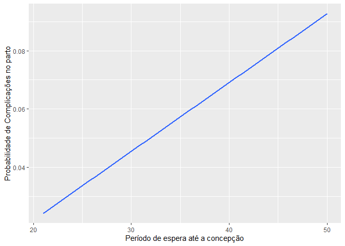

```r
#Gráfico: variável explicativa (mwp) x probabilidades estimadas .
library(ggplot2)
ggplot(banco, aes(x = mwp, y = PRED)) +
   stat_smooth(method = "glm", family = "binomial", se = FALSE) +
   labs(x = "Período de espera até a concepção",
       y = "Probabilidade de Complicações no parto")
```

## Perfil para obtenção de valores Preditos

```r
#Função para estimar probabilidades de perfis
prob<-function(vag.disch,mwp,parity.23,parity.4)
  { 1 /(1+exp(-( -3.83466 + (1.30702 *vag.disch) + ( 0.04664  *mwp) +
       (-1.38068*parity.23) + (-1.30293*parity.4))))
}
```

[output not shown]